# lab7

Zeyuan Fang

9/22/2021

upi:zfan253  
id:556588804

## Data desciption

We are going to the use a subset of the automobile data set that was used in Lab 6. In particular, the variables wheel.base, length, height, highway.mpg and price are considered in this lab. To concentrate, we can produce a subset data frame auto2 as follows:

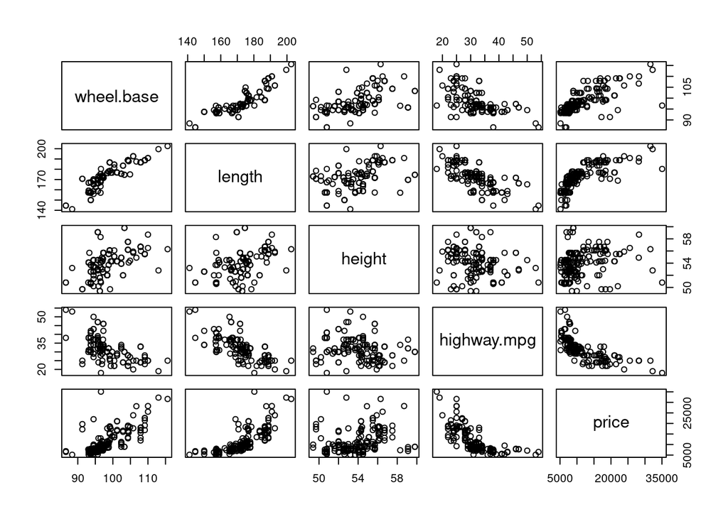

```r
auto = read.csv("automobile.csv", stringsAsFactors=TRUE)
auto2 = auto[,c("wheel.base", "length", "height", "highway.mpg", "price")]
pairs(auto2)
```

## Tasks

Loading packages..

```r
library(splines)
library(gam)
library(parallel)
```

## Modelling Nonlinear Relationship

#### Q1.Find all polynomial regression models for degrees 1 to 5.

```r
polymodels <- list(NULL)
for (i in 1:5){
  print(r <- lm(price ~ poly(highway.mpg, i, raw=TRUE), data=auto2))
  polymodels[[i]] =r
}
```

```
##
## Call:
## lm(formula = price ~ poly(highway.mpg, i, raw = TRUE), data = auto2)
##
## Coefficients:
##                      (Intercept)  poly(highway.mpg, i, raw = TRUE)
##                          32468.3                            -655.3
##
##
## Call:
## lm(formula = price ~ poly(highway.mpg, i, raw = TRUE), data = auto2)
##
## Coefficients:
##                       (Intercept)  poly(highway.mpg, i, raw = TRUE)1
##                          70368.86                           -2975.42
## poly(highway.mpg, i, raw = TRUE)2
##                             34.12
##
##
## Call:
## lm(formula = price ~ poly(highway.mpg, i, raw = TRUE), data = auto2)
##
## Coefficients:
##                       (Intercept)  poly(highway.mpg, i, raw = TRUE)1
##                        93247.4598                         -5070.7914
## poly(highway.mpg, i, raw = TRUE)2  poly(highway.mpg, i, raw = TRUE)3
##                           95.5198                            -0.5756
##
##
## Call:
## lm(formula = price ~ poly(highway.mpg, i, raw = TRUE), data = auto2)
##
## Coefficients:
##                       (Intercept)  poly(highway.mpg, i, raw = TRUE)1
##                         5.036e+04                          2.711e+02
## poly(highway.mpg, i, raw = TRUE)2  poly(highway.mpg, i, raw = TRUE)3
##                        -1.456e+02                          4.103e+00
## poly(highway.mpg, i, raw = TRUE)4
##                        -3.292e-02
##
##
## Call:
## lm(formula = price ~ poly(highway.mpg, i, raw = TRUE), data = auto2)
##
## Coefficients:
##                       (Intercept)  poly(highway.mpg, i, raw = TRUE)1
##                         4.573e+05                         -6.407e+04
## poly(highway.mpg, i, raw = TRUE)2  poly(highway.mpg, i, raw = TRUE)3
##                         3.804e+03                         -1.136e+02
## poly(highway.mpg, i, raw = TRUE)4  poly(highway.mpg, i, raw = TRUE)5
##                         1.673e+00                         -9.621e-03
```

#### Q2. Superimpose them all in one scatter plot of the data. What do you generally observe in the fitted curve when the polynomial degree increases?

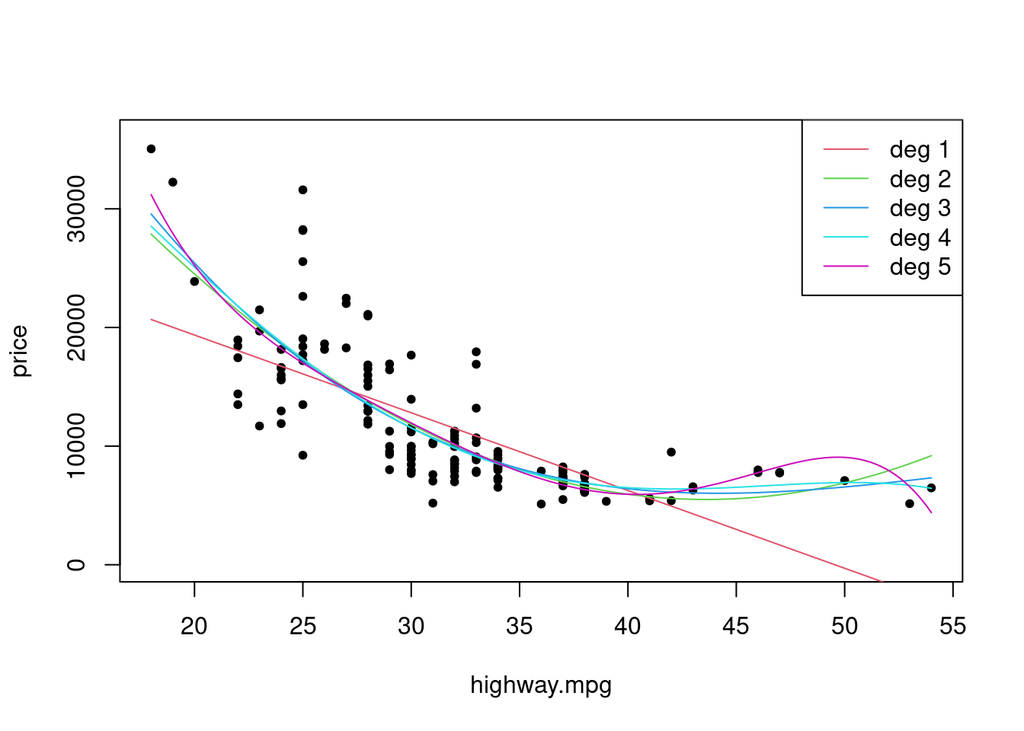

```r
with(auto2,plot(highway.mpg,price,ylim=c(0,max(price)+1000),pch=20))
for(i in 1:5){
  m <- lm(price ~ poly(highway.mpg, i, raw=TRUE), data=auto2)
  newX = data.frame(highway.mpg=seq(min(auto2$highway.mpg),max(auto2$highway.mpg),0.1))
  pred <- predict(m,newX)
  lines(newX$highway.mpg,pred,col=i+1)
}
legend("topright",paste("deg",1:5),col=1:5+1,lty=1)
```

As degree increases, the fitted curve get better fitting to the points.

#### Q3. Find the BIC-selected polynomial regression model. (You may consider using the residuals provided by the lm() fit`.) Do you think this is a reasonable fit?

```r
n = nrow(auto2)
lapply(1:5,function(i){
  m<- lm(price~poly(highway.mpg,i),data=auto2)
  #Use loglikelihood
  #-2*logLik(m) + log(n)*length(m$coefficients)

  #use RSS
  n*log(sum(m$residuals^2)) + log(n)*(length(m$coefficients))
})
```

```
## [[1]]
## [1] 3458.781
##
## [[2]]
## [1] 3408.963
##
## [[3]]
## [1] 3412.252
##
## [[4]]
## [1] 3416.798
##
## [[5]]
## [1] 3417.736
```

Here we use RSS to compute BIC instead of likelihood, and we ignored the constant.  
BIC tells us the degree 2 model is the best.  
Although it is not a good idea to use BIC for high-degree polynomials model selections, I think BIC happen to pick a reasonable model here, since degree 1 is obviously under-fitting and has large bias. And high degree may cause over-fitting. Thus model with degree 2 is a reasonable model to me.

## Generalised Additive Models

#### Q4. Fit a GAM to the data set, using a smoothing spline with 5 degrees of freedom for each predictor variable: wheel.base, length, height, highway.mpg. Create the plots for all the additive terms in the model.

```r
(gam.m1 = gam(price ~ s(wheel.base, 5)+s(length, 5)+s(height,5)+s(highway.mpg,5), data=auto2))
```

```
## Call:
## gam(formula = price ~ s(wheel.base, 5) + s(length, 5) + s(height,
##     5) + s(highway.mpg, 5), data = auto2)
##
## Degrees of Freedom: 158 total; 138.0003 Residual
## Residual Deviance: 885845691
```

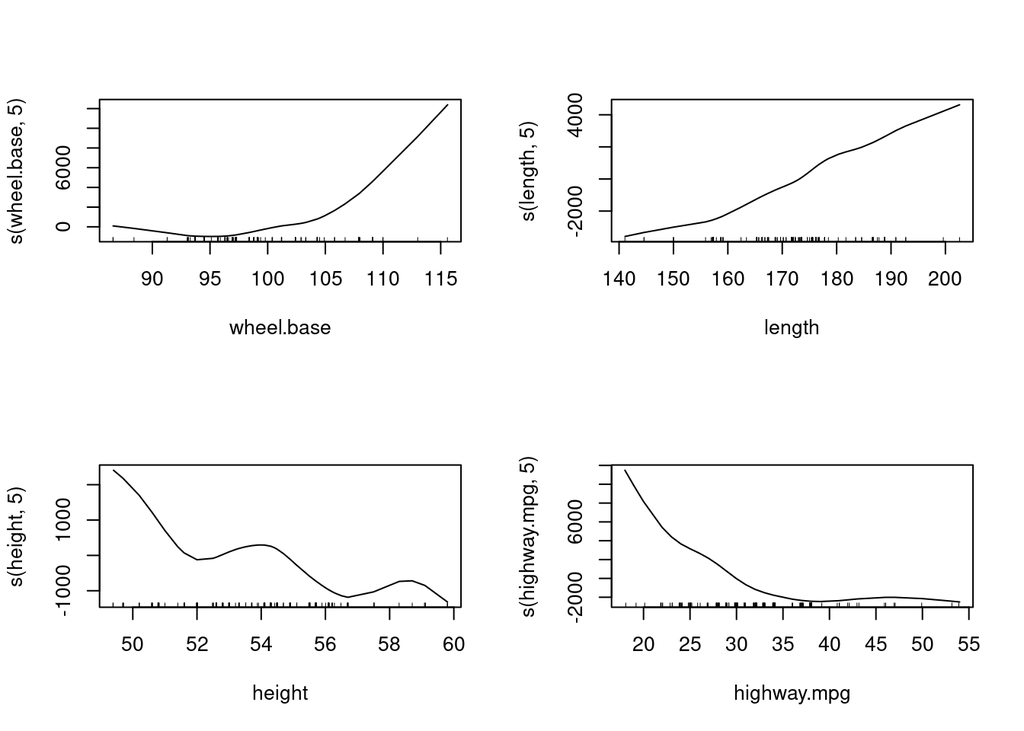

```r
par(mfrow=c(2,2))
plot(gam.m1)
```

#### Q5 Use your GAM to predict the price value for a new observation: wheel.base = 110, length = 190, height = 55, highway.mpg = 25.

```r
newdata <- data.frame(wheel.base = 110, length = 190, height = 55, highway.mpg = 25)
predict(r,newdata)
```

```
##        1
## 17000.99
```

#### Q6 Re-fit your GAM by adjusting manually the degrees of freedom of smoothing splines used for the additive terms until the fit visually looks reasonable to you. Provide some arguments.

```r
gam.m1 = gam(price ~ s(wheel.base, 2)+s(height,5)+s(highway.mpg,5), data=auto2)
gam.m2 = gam(price ~ s(wheel.base, 2)+length+s(height,5)+s(highway.mpg,5), data=auto2)
gam.m3 = gam(price ~ s(wheel.base, 5)+s(length,5)+s(height,5)+s(highway.mpg,5), data=auto2)
anova(gam.m1,gam.m2,gam.m3,test="F")
```

```
## Analysis of Deviance Table
##
## Model 1: price ~ s(wheel.base, 2) + s(height, 5) + s(highway.mpg, 5)
## Model 2: price ~ s(wheel.base, 2) + length + s(height, 5) + s(highway.mpg,
##     5)
## Model 3: price ~ s(wheel.base, 5) + s(length, 5) + s(height, 5) + s(highway.mpg,
##     5)
##   Resid. Df Resid. Dev     Df Deviance      F   Pr(>F)
## 1       146 1014410935
## 2       145  960221033 1.0000 54189902 8.4419 0.004272 **
## 3       138  885845691 6.9999 74375342 1.6552 0.125060
## ---
## Signif. codes:  0 '***' 0.001 '**' 0.01 '*' 0.05 '.' 0.1 ' ' 1
```

## Cross-validation for Regression Splines

#### Q7 For cubic regression splines, let us consider using knots that are evenly distributed between the two extreme values (minimum and maximum) of the predictor variable, but excluding the two extreme values. That is, given the number of knots, m, we create the knots as follow:

```r
attach(auto2)
m = 5            # number of knots
(rg = range(highway.mpg))
```

```
## [1] 18 54
```

```r
(knots = seq(rg[1], rg[2], length=m+2)[-c(1,m+2)])
```

```
## [1] 24 30 36 42 48
```

```r
detach(auto2)
```

```r
(r = lm(price ~ bs(highway.mpg, knots=knots, degree=3), data=auto2))
```

```
##
## Call:
## lm(formula = price ~ bs(highway.mpg, knots = knots, degree = 3),
##     data = auto2)
##
## Coefficients:
##                                 (Intercept)
##                                       39235
## bs(highway.mpg, knots = knots, degree = 3)1
##                                      -30775
## bs(highway.mpg, knots = knots, degree = 3)2
##                                      -12609
## bs(highway.mpg, knots = knots, degree = 3)3
##                                      -31377
## bs(highway.mpg, knots = knots, degree = 3)4
##                                      -30187
## bs(highway.mpg, knots = knots, degree = 3)5
##                                      -36027
## bs(highway.mpg, knots = knots, degree = 3)6
##                                      -27229
## bs(highway.mpg, knots = knots, degree = 3)7
##                                      -36376
## bs(highway.mpg, knots = knots, degree = 3)8
##                                      -32806
```

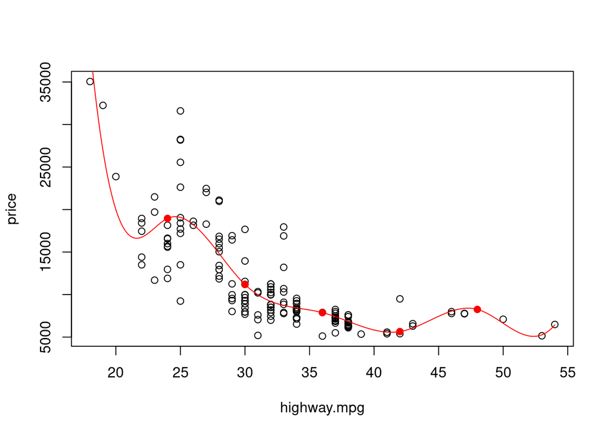

```r
yhat = predict(r, newX)
with(auto2, plot(highway.mpg, price))
lines(newX$highway.mpg, yhat, col="red")
points(knots, predict(r, data.frame(highway.mpg=knots)), col="red", pch=19)  # add knots
```

#### Q8. Use 10-fold cross-validation to find an appropriate value for m. Consider m = 1, 2, …, 5 in your CV study. Explain why you have used the technique of same subsamples.

Same subsamples does not change the variation of the estimated PE of any method, but it helps greatly when comparing their relative performance.

```r
M = 5
n = nrow(auto2)
R = 5
K=10
mse = matrix(nrow=R*K,ncol=M)

test.set <- function(i, n, K=10) {
  if(i < 1 || i > K)
    stop(" i out of range (1, K)")
  start = round(1 + (i-1) * n / K)
  end = ifelse(i == K, n, round(i * n / K))
  start:end
}

test.set(2,n)
```

```
##  [1] 17 18 19 20 21 22 23 24 25 26 27 28 29 30 31 32
```

```r
set.seed(769)           # set a random seed

for(i in 1:R) {                  # for each repetition
  ind = sample(n)
  for(k in 1:K) {                # for each fold
    index = ind[test.set(k, n, K)]
    test = auto2[index,]
    train = auto2[-index,]
    for(m in 1:M) {     # for each number of knots (method)
      rg = range(train$highway.mpg)
      knots = seq(rg[1], rg[2], length=m+2)[-c(1,m+2)]
      r = lm(price ~ bs(highway.mpg, knots=knots, degree=3), data=train)
      yhat = predict(r, test)         # prediction for test data
      mse[K*(i-1)+k,m] = mean( (test$price - yhat)^2 )
    }
  }
}
head(mse)
```

```
##          [,1]     [,2]     [,3]     [,4]     [,5]
## [1,] 11168314 12499114 13412534 11521493  8700850
## [2,] 13513059 13723898 13701684 13529802 11360438
## [3,] 13663515 15319866 10395095  5770098 20123526
## [4,]  9456285  9572194  8267966  6279390  5471586
## [5,] 27865360 27551081 26152620 22755622 21148166
## [6,] 19151564 20156735 19992940 16713150 14384632
```

```r
(pe = cbind(m=1:M, mse=colMeans(mse)))
```

```
##      m      mse
## [1,] 1 12551634
## [2,] 2 12885215
## [3,] 3 11964811
## [4,] 4 11843191
## [5,] 5 11677553
```

```r
(mmin = which.min(pe[,2]))
```

```
## [1] 5
```

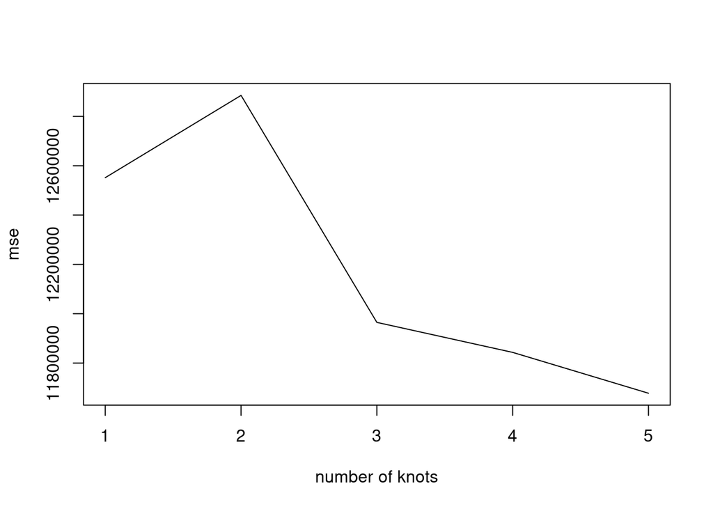

```r
plot(pe[,1], pe[,2], type="l", xlab="number of knots", ylab="mse")
```

#### Q9. Find your final model and show it in a scatter plot of the two variables.

My final model would use 5 knots.

```r
attach(auto2)
m = 5            # number of knots
(rg = range(highway.mpg))
```

```
## [1] 18 54
```

```r
(knots = seq(rg[1], rg[2], length=m+2)[-c(1,m+2)])
```

```
## [1] 24 30 36 42 48
```

```r
detach(auto2)
(r = lm(price ~ bs(highway.mpg, knots=knots, degree=3), data=auto2))
```

```
##
## Call:
## lm(formula = price ~ bs(highway.mpg, knots = knots, degree = 3),
##     data = auto2)
##
## Coefficients:
##                                 (Intercept)
##                                       39235
## bs(highway.mpg, knots = knots, degree = 3)1
##                                      -30775
## bs(highway.mpg, knots = knots, degree = 3)2
##                                      -12609
## bs(highway.mpg, knots = knots, degree = 3)3
##                                      -31377
## bs(highway.mpg, knots = knots, degree = 3)4
##                                      -30187
## bs(highway.mpg, knots = knots, degree = 3)5
##                                      -36027
## bs(highway.mpg, knots = knots, degree = 3)6
##                                      -27229
## bs(highway.mpg, knots = knots, degree = 3)7
##                                      -36376
## bs(highway.mpg, knots = knots, degree = 3)8
##                                      -32806
```

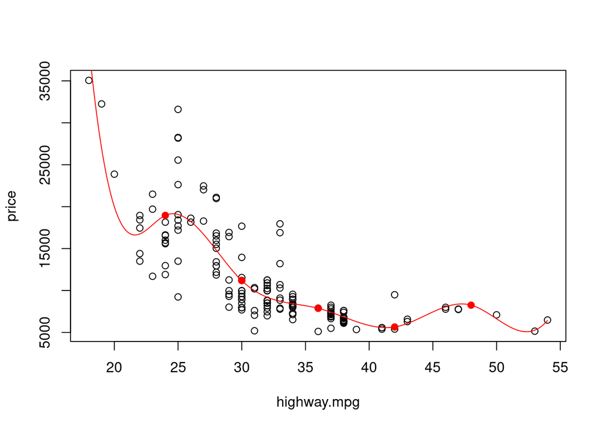

```r
yhat = predict(r, newX)
with(auto2, plot(highway.mpg, price))
lines(newX$highway.mpg, yhat, col="red")
points(knots, predict(r, data.frame(highway.mpg=knots)), col="red", pch=19)  # add knots
```

## Jackknifing and Parallel Computing

#### Q10. Use the Jackknifing technique (with a 90% for training and 10% for testing) to find an appropriate degree for polynomial regression as in Tasks 1-3. Use R = 200 as the number of repetitions. Show the curve of the selected model in a scatter plot of the data.

```r
n = nrow(auto2)
k = round(n * 0.10)
deg =1:5
R = 200                  # number of repetitions
mse = matrix(nrow=R, ncol=length(deg))   # pre-allocate space
dim(mse)
```

```
## [1] 200   5
```

```r
set.seed(769)           # set a random seed

for(i in 1:R) {
    index = sample(n, k)
    test = auto2[index,]
    train = auto2[-index,]
  for(j in deg) {
    r = lm(price ~poly(highway.mpg,degree=j,raw=TRUE), data= train)
    yhat = predict(r, test)     # prediction for test data
    mse[i,j] = mean( (test$price - yhat)^2 )
  }
}
head(mse)
```

```
##          [,1]     [,2]     [,3]     [,4]     [,5]
## [1,] 17866666 11605652 11615244 11469612 12825072
## [2,] 31450376 20921113 20459753 20333429 21032086
## [3,]  8131521  5635243  5915592  5970972  5840896
## [4,] 16221436 16520127 16638187 16620453 16441710
## [5,] 32101923 28856157 30726335 30602462 30124042
## [6,] 25500103 18701478 18689463 18490488 19208643
```

```r
(pe = cbind(deg=1:5, mse=colMeans(mse)))
```

```
##      deg      mse
## [1,]   1 18682215
## [2,]   2 13262573
## [3,]   3 13231100
## [4,]   4 13844958
## [5,]   5 14299405
```

```r
(deg_min = which.min(pe[,2]))
```

```
## [1] 3
```

The degree 3 of polynomial model is the best according to jackknifing.

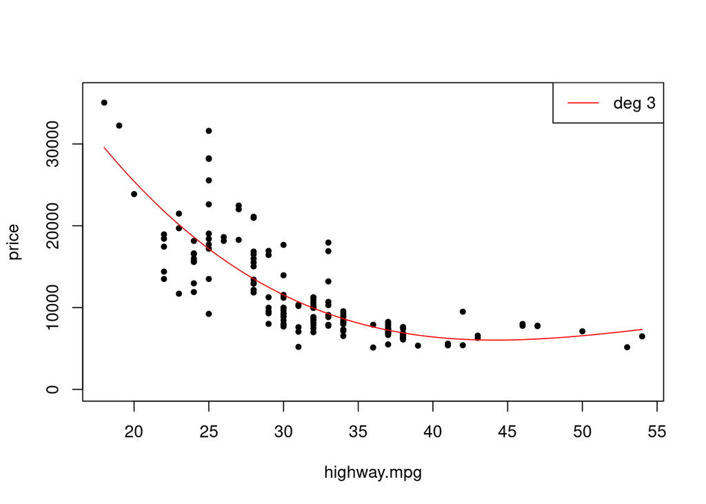

```r
with(auto2,plot(highway.mpg,price,ylim=c(0,max(price)+1000),pch=20))
m <- lm(price ~ poly(highway.mpg, 3, raw=TRUE), data=auto2)
newX = data.frame(highway.mpg=seq(min(auto2$highway.mpg),max(auto2$highway.mpg),0.1))
pred <- predict(m,newX)
lines(newX$highway.mpg,pred,col='red')
legend("topright",paste("deg",3),col='red',lty=1)
```

#### Q11. Rewrite/reorganise your code so that each repetition can be carried out independently. Perform the Jackknifing selection of the polynomial degree using parallel computing, with function mclapply().Compare the timings, when 1, 5, 10 or 20 cores are used (so you have to do this on a VM).

```r
n = nrow(auto2)
k = round(n * 0.10)
R = 200                  # number of repetitions
mse = matrix(nrow=R, ncol=5)   # pre-allocate space
deg =5
set.seed(769)
lapply(c(1,5,10,20),
function(nc) system.time({

mse <- mclapply(1:R,function(x){
  mse <- numeric(deg)
  index = sample(n, k)
  test = auto2[index,]
  train = auto2[-index,]
  for(j in 1:deg) {
    r = lm(price ~poly(highway.mpg,degree=j,raw=TRUE), data= train)
    yhat = predict(r, test)     # prediction for test data
    mse[j] = mean( (test$price - yhat)^2 )
  }
  mse

} ,mc.cores = nc)
  mse = matrix(data=unlist(mse),nrow=R,ncol=deg,byrow=T)
  pe = cbind(deg=1:5, mse=colMeans(mse))
  print(paste("The selected degree is ",which.min(pe[,2])))
}
))
```

```
## [1] "The selected degree is  3"
## [1] "The selected degree is  2"
## [1] "The selected degree is  2"
## [1] "The selected degree is  3"
```

```
## [[1]]
##    user  system elapsed
##   1.432   0.000   1.432
##
## [[2]]
##    user  system elapsed
##   0.002   0.008   0.480
##
## [[3]]
##    user  system elapsed
##   1.378   0.448   0.278
##
## [[4]]
##    user  system elapsed
##   1.621   0.671   0.173
```

#### Q12. For results to be reproducible, it is better to use random seeds. Investigate and demonstrate how this can be achieved when mclapply() is used.

If we put sample() in mclapply, we will get different samples for different mc.cores.  
So a good idea is getting sample before mclapply(), then there is no random process in mclapply(), which can promise the result reproducible.

```r
n = nrow(auto2)
k = round(n * 0.10)
R = 200                  # number of repetitions
mse = matrix(nrow=R, ncol=5)   # pre-allocate space
deg =5
set.seed(769)
samples_list <- lapply(1:R, function(i)index = sample(n, k))
lapply(c(1,5,10,20),
function(nc) system.time({
  mse <- mclapply(samples_list,function(index){
    mse <- numeric(deg)
    for(j in 1:deg) {
    test = auto2[index,]
    train = auto2[-index,]
    r = lm(price ~poly(highway.mpg,degree=j,raw=TRUE), data= train)
    yhat = predict(r, test)     # prediction for test data
    mse[j] = mean( (test$price - yhat)^2 )
  }
  mse

} ,mc.cores = nc)
#  skip.streams(nc)
  mse = matrix(data=unlist(mse),nrow=R,ncol=deg,byrow=T)
  pe = cbind(deg=1:5, mse=colMeans(mse))
  print(paste("The selected degree is ",which.min(pe[,2])))
}
))
```

```
## [1] "The selected degree is  3"
## [1] "The selected degree is  3"
## [1] "The selected degree is  3"
## [1] "The selected degree is  3"
```

```
## [[1]]
##    user  system elapsed
##   2.093   0.004   2.098
##
## [[2]]
##    user  system elapsed
##   1.713   0.220   0.559
##
## [[3]]
##    user  system elapsed
##   1.938   0.582   0.303
##
## [[4]]
##    user  system elapsed
##   2.053   0.876   0.192
```

The selected degree is 3, which is a reproducible result and comply with the result of non-parallel computing.

## Summary

In this lab, we explore non-linearity model and resampling techniques. First we try polynomial regression for different degrees and GAM model with smoothing spline. We train and test the best parameters setting for these models based on the entire data set. Then we bring in resampling methods like cross-validation and Jackknifing, which can offer us a more convincing result for fine-tuning model parameters. Since these resampling techniques need much more computation, we also consider using parallel computing to speed up and how to generate reproducible result in a parallel computing environment.